# proy_1

```python
import pandas as pd
import numpy as np
import networkx as nx
import seaborn as sns
import matplotlib.pyplot as plt
import sys, os

sys.path.insert(1, os.path.join(sys.path[0], '../../openAi/TS_analysis_TOPIC9/'))
path = os.path.join('..','..','food_trade_network','AOFFTN','Exploration_V3','antifragilidades_datasets','af.csv')

from pyts_utils import descriptive_tools
from sklearn.decomposition import PCA
from sklearn.metrics import pairwise_distances
from cdlib import algorithms, ensemble,evaluation
from cdlib import viz
```

### Dimensionality reduction and time series community detection.

In this project I use skills like data wrangling, dimensionality reduction, time series analysis, descriptive statistics, network analysis and community detection algorithms.

To give some context, I was interested in performing an exploratory analysis of a recently defined measure of antifragility of countries, which is basically an indicator that tries to say something about the alimentary vulnerability of countries and is computed using data from the global food trade network. The main objective of my project was to find groups of countries with similar behavior over time as measured by this indicator we called antifragility. I followed two approaches. One using real values and the other considering similar geometric profiles.

Then, I also related the aggregate behavior (ecological behavior) of the groups found against some other variables. In particular I used GDP, Population, number of countries with which one exporter trade, and others using distances in km between countries, price (in 1000 US$) of the food traded and its associated quantity (in tonnes).

# -------------------------------------------------------------------------------------------------

Computing the antifragility indicator, 8 different variants were considered. To facilitate further analysis, and work with matrices instead of tensors, I performed dimensionality reduction using PCA to obtain 1 final feature to find similarities among countries over time.

```python
af=pd.read_csv(path)
af = af.rename(columns={'Unnamed: 0':'country','Unnamed: 1':'year'})
```

```python
af.head()
```

|  | country | year | af_in_pr | af_in_vl | af_ex_pr | af_ex_vl | af_in_pr2 | af_in_vl2 | af_ex_pr2 | af_ex_vl2 |
| --- | --- | --- | --- | --- | --- | --- | --- | --- | --- | --- |
| 0 | Afghanistan | 1987 | NaN | NaN | 0.065936 | 0.237313 | NaN | NaN | 0.061285 | 0.256803 |
| 1 | Afghanistan | 1988 | NaN | NaN | NaN | NaN | NaN | NaN | NaN | NaN |
| 2 | Afghanistan | 1989 | NaN | NaN | NaN | NaN | NaN | NaN | NaN | NaN |
| 3 | Afghanistan | 1990 | NaN | NaN | 0.145686 | 0.138787 | NaN | NaN | 0.123340 | 0.169495 |
| 4 | Afghanistan | 1991 | NaN | NaN | 0.080414 | 0.050705 | NaN | NaN | 0.059234 | 0.078926 |

```python
af.iloc[:,2:].corr()
```

|  | af_in_pr | af_in_vl | af_ex_pr | af_ex_vl | af_in_pr2 | af_in_vl2 | af_ex_pr2 | af_ex_vl2 |
| --- | --- | --- | --- | --- | --- | --- | --- | --- |
| af_in_pr | 1.000000 | 0.671100 | -0.047607 | -0.011621 | 0.957643 | 0.785956 | -0.036705 | -0.024999 |
| af_in_vl | 0.671100 | 1.000000 | -0.008078 | 0.026799 | 0.774187 | 0.959194 | -0.003471 | 0.016606 |
| af_ex_pr | -0.047607 | -0.008078 | 1.000000 | 0.692871 | -0.038237 | -0.015104 | 0.957657 | 0.802626 |
| af_ex_vl | -0.011621 | 0.026799 | 0.692871 | 1.000000 | -0.002612 | 0.016074 | 0.789997 | 0.957202 |
| af_in_pr2 | 0.957643 | 0.774187 | -0.038237 | -0.002612 | 1.000000 | 0.823725 | -0.028250 | -0.014912 |
| af_in_vl2 | 0.785956 | 0.959194 | -0.015104 | 0.016074 | 0.823725 | 1.000000 | -0.009681 | 0.004890 |
| af_ex_pr2 | -0.036705 | -0.003471 | 0.957657 | 0.789997 | -0.028250 | -0.009681 | 1.000000 | 0.831397 |
| af_ex_vl2 | -0.024999 | 0.016606 | 0.802626 | 0.957202 | -0.014912 | 0.004890 | 0.831397 | 1.000000 |

Using simple correlations, we already see that af_ex_xx and af_in_xx are not linearly proportional to each other (low correlation). Faced with two possible options, I decided to use af_ex_xx given that they have less number of NaNs and if necessary, I could explore af_in_xx analogously.

```python
af=af.iloc[:,[0,1,4,5,8,9]]
```

```python
af.iloc[:,2:].corr()
```

|  | af_ex_pr | af_ex_vl | af_ex_pr2 | af_ex_vl2 |
| --- | --- | --- | --- | --- |
| af_ex_pr | 1.000000 | 0.692871 | 0.957657 | 0.802626 |
| af_ex_vl | 0.692871 | 1.000000 | 0.789997 | 0.957202 |
| af_ex_pr2 | 0.957657 | 0.789997 | 1.000000 | 0.831397 |
| af_ex_vl2 | 0.802626 | 0.957202 | 0.831397 | 1.000000 |

```python
af.info()
```

```
<class 'pandas.core.frame.DataFrame'>
RangeIndex: 7533 entries, 0 to 7532
Data columns (total 6 columns):
 #   Column     Non-Null Count  Dtype
---  ------     --------------  -----
 0   country    7533 non-null   object
 1   year       7533 non-null   int64
 2   af_ex_pr   4660 non-null   float64
 3   af_ex_vl   4663 non-null   float64
 4   af_ex_pr2  4660 non-null   float64
 5   af_ex_vl2  4663 non-null   float64
dtypes: float64(4), int64(1), object(1)
memory usage: 353.2+ KB
```

We see that in reality, we only have 4660 non-null observations.

Let's first project the data to a two dimension space.

```python
toproject_af=af.dropna(axis=0)  # dropna NaNs in order to apply PCA
```

```python
toproject_af.iloc[:,2:].describe()
```

|  | af_ex_pr | af_ex_vl | af_ex_pr2 | af_ex_vl2 |
| --- | --- | --- | --- | --- |
| count | 4660.000000 | 4.660000e+03 | 4660.000000 | 4660.000000 |
| mean | 0.003813 | 8.307523e-03 | 0.003736 | 0.007995 |
| std | 0.152067 | 1.518882e-01 | 0.144719 | 0.146449 |
| min | -1.000000 | -1.000000e+00 | -0.801286 | -0.801286 |
| 25% | -0.036560 | -3.325984e-02 | -0.038431 | -0.035989 |
| 50% | 0.000000 | 1.650346e-07 | 0.000898 | 0.001854 |
| 75% | 0.038602 | 4.616321e-02 | 0.042336 | 0.046693 |
| max | 1.000000 | 1.000000e+00 | 0.801286 | 0.801286 |

All the features have approximately the same dispersion and mean. Therefore, we can feel confident to directly apply pca

```python
pca_2d =  PCA(n_components=2).fit(toproject_af.iloc[:,2:])
```

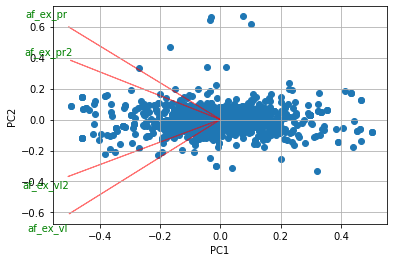

```python
descriptive_tools.pca_biplot(score= pca_2d.fit_transform(toproject_af.iloc[:,2:]), coeff=pca_2d.components_. T, labels= toproject_af.iloc[:,2:].columns)
```

```python
pca=PCA(n_components=1,random_state=1).fit(toproject_af.iloc[:,2:])
```

```python
clean_afs = pca.fit_transform(toproject_af.iloc[:,2:])
```

```python
pca.explained_variance_ratio_.cumsum()
```

```
array([0.87781833])
```

87.8% seems reasonable

```python
clean_afs = pd.DataFrame(data=clean_afs,columns=['af_ex_pca'])
```

```python
clean_afs['country'] = toproject_af.reset_index()['country']
clean_afs['year'] = toproject_af.reset_index()['year']
```

```python
clean_afs
```

|  | af_ex_pca | country | year |
| --- | --- | --- | --- |
| 0 | -0.299329 | Afghanistan | 1987 |
| 1 | -0.276898 | Afghanistan | 1990 |
| 2 | -0.122803 | Afghanistan | 1991 |
| 3 | -0.082964 | Afghanistan | 1992 |
| 4 | 0.061521 | Afghanistan | 1993 |
| ... | ... | ... | ... |
| 4655 | -0.012813 | Viet Nam | 2013 |
| 4656 | 0.230696 | Viet Nam | 2014 |
| 4657 | -0.004328 | Viet Nam | 2015 |
| 4658 | 0.235808 | Viet Nam | 2016 |
| 4659 | 0.245684 | Viet Nam | 2017 |

4660 rows × 3 columns

```python
pivot_afex = clean_afs.pivot_table(index='year',columns='country',values='af_ex_pca')
pivot_afex=pivot_afex.drop(columns='Unspecified Area')
```

There are plenty of different proximity measures (similarity, dissimilarity, distances) and clustering algorithms. Moreover, we can map from the time domain to the frequency domain or to the topological domain (network). Some articles support the idea that clusters based on topological features of the interacting objects are capable of identifying more general clusters (in the network terminology, communities) than classical time series clustering algorithms. Therefore, here I decided to map from the time domain to the topological one using an $\epsilon$-NN network construction.

The pseudoalgorithm is as follows:

1. Select a proximity measure
2. Compute the proximity matrix from the time series objects
3. Construct a network considering nodes as time series objects and linking pairs of nodes when the proximity measure overcome a predefined threshold $\epsilon$
4. Apply a community detection algorithm

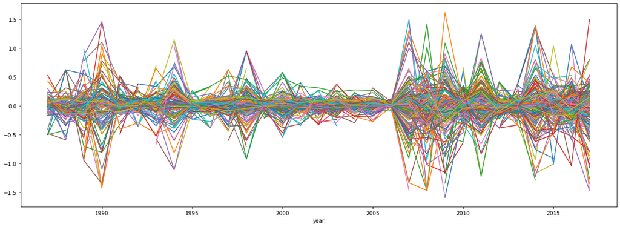

```python
pivot_afex.plot(legend=False,figsize=(20,7))
```

One possible apporach is to find similar countries based the magnitude of their antifragility time series. Given that the number of observations is small (31) we proceed using the standard lock-step euclidean distance. Note that other elastic proximities such as dynamic time warping are generally more powerful identifying dissimilarities between pairs of time series when the number of observations is greater than here. In this case, they would perform relatively equal, but it is much easier to implement euclidean distances.

```python
Distance_matrix = pd.DataFrame(pairwise_distances(pivot_afex.T,metric='nan_euclidean'),index=pivot_afex.columns,columns=pivot_afex.columns.copy())
```

```python
plt.figure(figsize=(20,7))
sns.heatmap(Distance_matrix)
```

[figure not shown]

Two algorithms that usually give good modularity values are Louvian and CNM (Clauset, Newman and Moore) (greedy modularity)

```python
def get_communities(Distance_matrix,epsilon):

    ## ϵ-NN network construction
    epsilon_NN = Distance_matrix[Distance_matrix < epsilon]
    epsilon_NN = epsilon_NN.fillna(0)

    G = nx.Graph()
    for country1,series in epsilon_NN.iteritems():
        for country2,proximity in series.iteritems():
            if not np.equal(proximity,0):
                G.add_edge(country1,country2)

    #Greedy_modul
    comm_greedy = algorithms.greedy_modularity(G)

    # louvain
    communities = algorithms.louvain(G)

    return G,communities,comm_greedy
```

In contrast to supervised learning algorithms, we don't have quality measures to tune hyperparameters and evluate the performance optimal performance of our algorithms. So the correct selection of $\epsilon$ is more an art than a science sometimes. It must be tailored by what your objectives are, what you are looking for using a clustering algorithm, etc.

Nevertheless, there are certain regularities. Threshold values close to the minimum possible for the considered proximity measure tend to create many small communities as we obtain a network which consist of only a few strongly connected nodes. High threshold values create a small number of big communities as we generate networks consisting of big connected components. Finally, it is recommended to use threshold values in the middle of the range and see if some interesing/useful pattern emerges. In this case a selected 2.5.

```python
G,communities,comm_greedy=get_communities(Distance_matrix,2.5)
print("AMI:",communities.adjusted_mutual_information(comm_greedy).score)
print("ARI:",communities.adjusted_rand_index(comm_greedy).score)
```

```
AMI: 0.3477270251525502
ARI: 0.3803670053518004
```

```python
print('Number of communities found by louvan and greedy modularity community detection algorithms:',len(communities.communities))
```

```
Number of communities found by louvan and greedy modularity community detection algorithms: 3
```

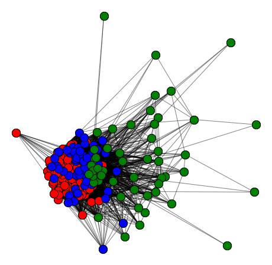

```python
_=viz.plot_network_clusters(G,communities)
```

```python
indices = [ index for index,group in enumerate(communities.communities) for count in group ]
countries = [c for g in communities.communities for c in g]
```

```python
df_communities = pd.DataFrame(data=np.c_[countries,indices],columns=['country','labels'])
```

```python
mergd_afex_communities = pivot_afex.T.merge(df_communities,on='country')
```

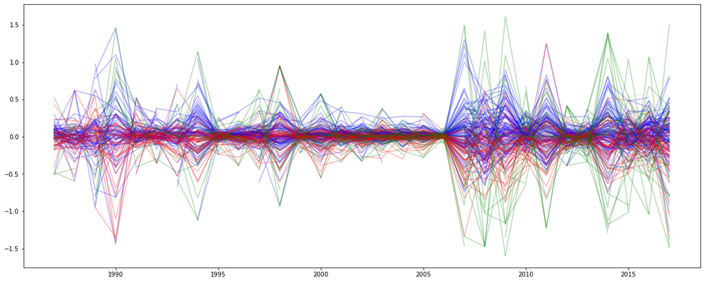

```python
fig,ax=plt.subplots(figsize=(20,8))
for i,color in zip(df_communities['labels'].unique(),['blue','red','green']):
    mergd_afex_communities[mergd_afex_communities['labels']==str(i)].T.drop(['country','labels']).plot(legend=False,c=color,alpha=0.3,ax=ax)
```

We can already identify the difference between the communities found. The green has the highest variance in some places but it is nonetheless more less symmetric around zero. The blue and red have a bias towards positive and negative values respectively. We can confirm this looking at the group average antifragility time series.

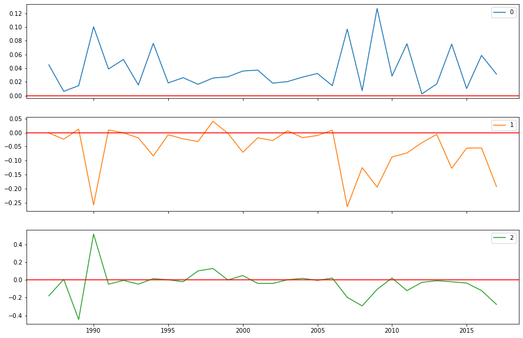

```python
ax=mergd_afex_communities.groupby('labels').mean().T.plot(subplots=True,figsize=(15,10))
for a in ax:
    a.axhline(0,c='red')
```

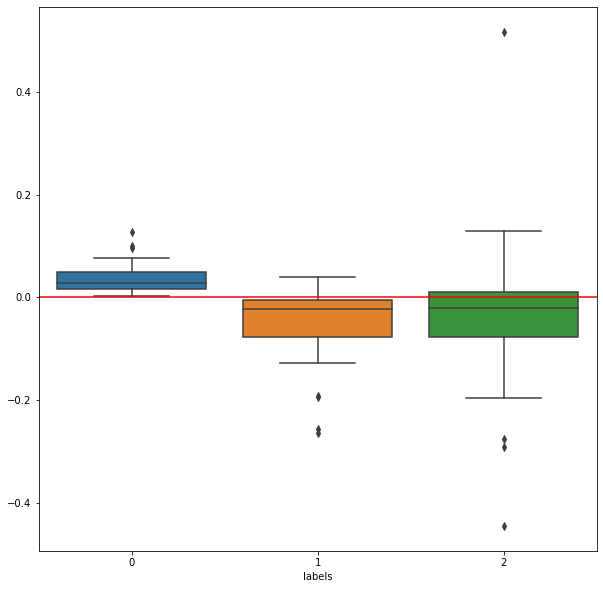

```python
fig,axs=plt.subplots(1,1,figsize=(10,10))

sns.boxplot(data=mergd_afex_communities.groupby('labels').mean().T,ax=axs)
_=axs.axhline(0,c='red')
```

Below is the number of countries per group and a world map showing the spatial distribution of the groups created using EXCEL.

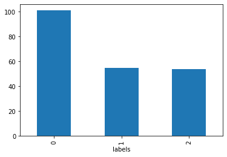

```python
_=(mergd_afex_communities.groupby('labels').count()['country']).plot.bar() # Number of countries per community
```

[figure not shown]

```python
pre_path = '../../food_trade_network/AOFFTN/Exploration_V3/'
```

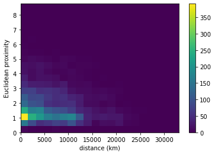

```python
D_copy = Distance_matrix.copy()

D_copy.columns.name='exporter'

D_copy.index.name='importer'

D_copy=D_copy.where(np.triu(np.ones(Distance_matrix.shape,dtype=bool),1)).stack().reset_index(name='corr_distance')

comparison_distances = pd.read_csv(pre_path+'pairing_data/for_distance_pairing/distances_countries_inKM.csv',index_col=0)

merged_spatial_structure = D_copy.merge(comparison_distances,on=['importer','exporter'])

_=plt.hist2d(y=merged_spatial_structure['corr_distance'],x=merged_spatial_structure['distance_Km'],bins=20)
plt.colorbar()
plt.xlabel('distance (km)')
_=plt.ylabel('Euclidean proximity')
```

```python
pop=pd.read_csv(pre_path+'pairing_data/Population_clean.csv',index_col=0)
gdp = pd.read_csv(pre_path+'pairing_data/GDP_clean.csv',index_col=0)
distance = pd.read_csv(pre_path+'pairing_data/for_distance_pairing/distances_year_ex_im.csv',index_col=0) # distances in Km
trade_info = pd.read_csv(pre_path+'pairing_data/for_distance_pairing/trade_matrix_final.csv',index_col=0)


merged_pop_communities = pop.merge(df_communities,how='inner',left_on='country.value',right_on='country').drop(columns='country.value',axis=1)
merged_gdp_communities = gdp.merge(df_communities,how='inner',left_on='country.value',right_on='country').drop(columns='country.value',axis=1)
merged_pop_communities = merged_pop_communities[['date','value','country','labels']]
merged_gdp_communities = merged_gdp_communities[['date','value','country','labels']]


merged_distances_ex_communities = distance.groupby(['exporter','Year']).mean().reset_index().merge(df_communities,how='inner',left_on='exporter',right_on='country').drop(columns='exporter',axis=1)
merged_distances_in_communities = distance.groupby(['importer','Year']).mean().reset_index().merge(df_communities,how='inner',left_on='importer',right_on='country').drop(columns='importer',axis=1)


trade_info_value = trade_info[trade_info['Unit'] == '1000 US$']
trade_info_quantity = trade_info[trade_info['Unit']=='tonnes']
merged_ex_food_value = trade_info_value.groupby(['exporter','Year']).mean().reset_index().merge(df_communities,how='inner',left_on='exporter',right_on='country').drop(columns='exporter',axis=1)
merged_ex_food_quantity = trade_info_quantity.groupby(['exporter','Year']).mean().reset_index().merge(df_communities,how='inner',left_on='exporter',right_on='country').drop(columns='exporter',axis=1)
merged_in_food_value = trade_info_value.groupby(['importer','Year']).mean().reset_index().merge(df_communities,how='inner',left_on='importer',right_on='country').drop(columns='importer',axis=1)
merged_in_food_quantity = trade_info_quantity.groupby(['importer','Year']).mean().reset_index().merge(df_communities,how='inner',left_on='importer',right_on='country').drop(columns='importer',axis=1)
```

Finally, I explored the relationships of these groups with other variables over time.

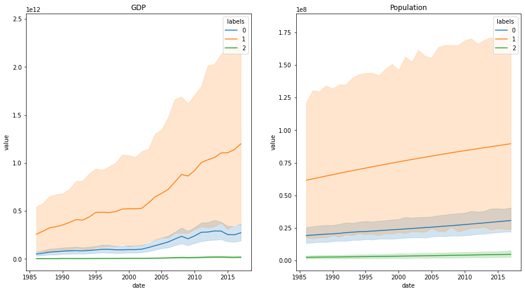

```python
fig,axs=plt.subplots(1,2,figsize=(15,8))
a=sns.lineplot(data=merged_gdp_communities,y='value',x='date',hue='labels',hue_order=df_communities['labels'].unique(),ax=axs[0])
b=sns.lineplot(data=merged_pop_communities[['date','value','country','labels']],y='value',x='date',hue='labels',hue_order=df_communities['labels'].unique(),ax=axs[1])
axs[0].set_title('GDP')
_=axs[1].set_title('Population')
```

```python
parametric_plot=merged_distances_ex_communities.groupby(['Year','labels']).mean().reset_index().merge(
    mergd_afex_communities.groupby('labels').mean().T.reset_index().melt(id_vars='index',value_name='antifragility').rename({'index':'Year'},axis=1),on=['Year','labels'])
```

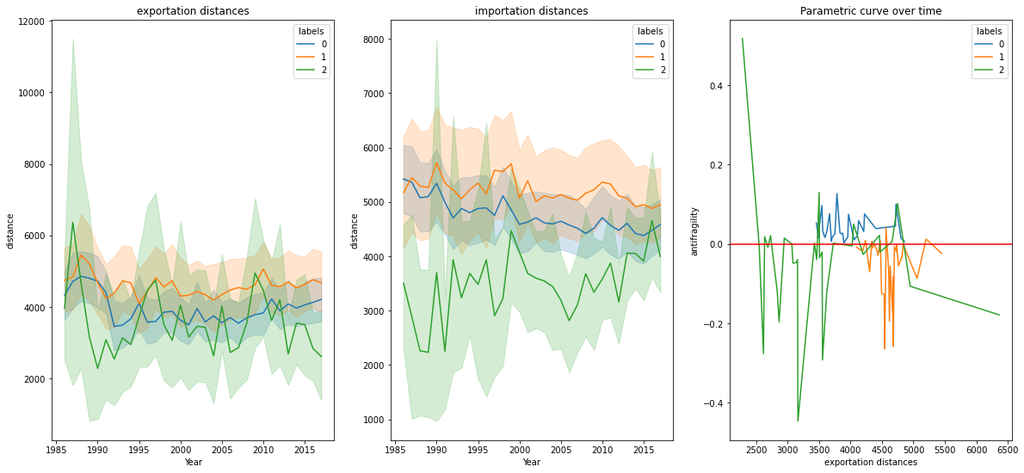

```python
fig,axs=plt.subplots(1,3,figsize=(20,9)) # 2.8
sns.lineplot(data=merged_distances_ex_communities,y='distance',x='Year',hue='labels',hue_order=df_communities['labels'].unique(),ax=axs[0])
sns.lineplot(data=merged_distances_in_communities,y='distance',x='Year',hue='labels',hue_order=df_communities['labels'].unique(),ax=axs[1])
sns.lineplot(data=parametric_plot,x='distance',y='antifragility',hue='labels')
axs[2].axhline(0,c='red')
axs[0].set_title('exportation distances')
axs[1].set_title('importation distances')
axs[2].set_title('Parametric curve over time')
axs[2].set_xlabel('exportation distances')
```

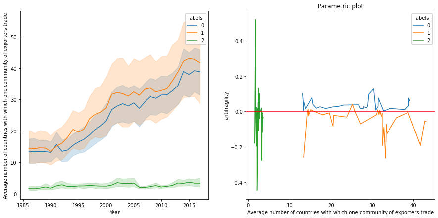

```python
numbers_exporters = distance.groupby(['exporter','Year']).count().reset_index().merge(df_communities,how='inner',left_on='exporter',right_on='country').drop(columns=['exporter','distance'],axis=1).rename({'importer':'# of countries'},axis=1)
numbers_importers = distance.groupby(['importer','Year']).count().reset_index().merge(df_communities,how='inner',left_on='importer',right_on='country').drop(columns=['importer','distance'],axis=1).rename({'exporter':'# of countries'},axis=1)

parametric_plot_numbers=numbers_exporters.groupby(['Year','labels']).mean().reset_index().merge(
    mergd_afex_communities.groupby('labels').mean().T.reset_index().melt(id_vars='index',value_name='antifragility').rename({'index':'Year'},axis=1),on=['Year','labels'])

fig,axs=plt.subplots(1,2,figsize=(15,7))
sns.lineplot(data=numbers_exporters,y='# of countries',x='Year',hue='labels',hue_order=df_communities['labels'].unique(),ax=axs[0])
# sns.lineplot(data=numbers_importers,y='# of countries',x='Year',hue='labels',hue_order=df_communities['labels'].unique(),ax=axs[1])
sns.lineplot(data=parametric_plot_numbers,x='# of countries',y='antifragility',hue='labels',ax=axs[1])
axs[1].axhline(0,c='red')
# axs[1].set_ylabel('Average number of countries with which one community of importers trade')
axs[1].set_xlabel('Average number of countries with which one community of exporters trade')
axs[0].set_ylabel('Average number of countries with which one community of exporters trade')
axs[1].set_title('Parametric plot')
```

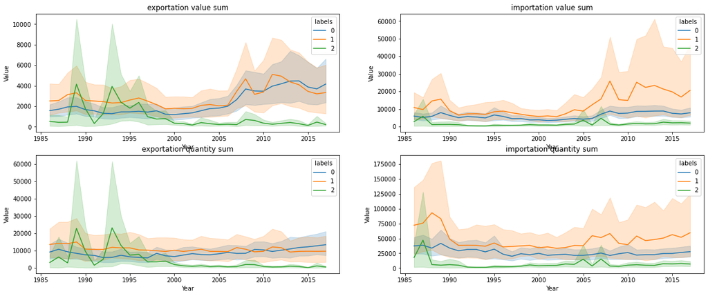

```python
fig,axs=plt.subplots(2,2,figsize=(20,8))
sns.lineplot(data=merged_ex_food_value,y='Value',x='Year',hue='labels',hue_order=['0','1','2'],ax=axs[0,0])
sns.lineplot(data=merged_in_food_value,y='Value',x='Year',hue='labels',hue_order=['0','1','2'],ax=axs[0,1])
axs[0,0].set_title('exportation value sum')
axs[0,1].set_title('importation value sum')

sns.lineplot(data=merged_ex_food_quantity,y='Value',x='Year',hue='labels',hue_order=['0','1','2'],ax=axs[1,0])
sns.lineplot(data=merged_in_food_quantity,y='Value',x='Year',hue='labels',hue_order=['0','1','2'],ax=axs[1,1])
axs[1,0].set_title('exportation quantity sum')
axs[1,1].set_title('importation quantity sum')
```

```python
from sklearn.preprocessing import power_transform
```

```python
yeo_johnson=power_transform(pivot_afex.T,standardize=False)
```

```python
yeo_johnson = pd.DataFrame(data=yeo_johnson,index=ex_pr.dropna(axis=1).columns.values,columns=ex_pr.dropna(axis=1).index)
```

[output not shown]